# A2.2 LDA y árboles de decisión

Andrés Luna de la Garza #608994

1. Aquí se importa la librería implementada en la actividad prevía y se crea la variable binaria y_bin, que toma el valor 1 si Classification == 2, y 0 en caso contrario para poder analizar los datos. También, se divide el conjunto de datos en entrenamiento (80%) y prueba (20%) y se imprimen las proporciones de datos originales, entrenamiento y prueba.

```python
import pandas as pd
from sklearn.model_selection import train_test_split
data= pd.read_csv("DataR2.csv")
data["y_bin"]=(data["Classification"]==2).astype(int)
X= data.drop(["Classification", "y_bin"], axis=1)
y= data["y_bin"]

X_train, X_test, y_train, y_test = train_test_split(X, y, train_size=0.8, stratify=y, random_state=42)
print("Repartición total de clases:")
print(y.value_counts(normalize=True))
print(" ")
# Revisar la distribución en el conjunto de entrenamiento
print("Repartición del set de entrenamiento:")
print(y_train.value_counts(normalize=True))
print(" ")
# Revisar la distribución en el conjunto de prueba
print("Repartición del set de prueba:")
print(y_test.value_counts(normalize=True))
```

```
Repartición total de clases:
y_bin
1    0.551724
0    0.448276
Name: proportion, dtype: float64

Repartición del set de entrenamiento:
y_bin
1    0.554348
0    0.445652
Name: proportion, dtype: float64

Repartición del set de prueba:
y_bin
1    0.541667
0    0.458333
Name: proportion, dtype: float64
```

2. Para este, se realiza una regresión logística simple y se demuestra los resultados del modelo. En base a este, se seleccionan las variables de Glucose y Resistin debido a que cuentan con el pvalue más bajo en comparación con las demas variables.

```python
import statsmodels.api as sm
X_train_sm= sm.add_constant(X_train)
model= sm.GLM(y_train, X_train_sm, family= sm.families.Binomial())
result= model.fit()
print(result.summary())
#tomando en cuenta que las dos variables con menor pvalue son glucose y resistin, se contemplaran aquellas para el analisis
var= ["Glucose", "Resistin"]
X_trainvar= X_train[var]
X_testvar= X_test[var]
print(" ")
print("Nuevas dimensiones de X_train:", X_trainvar.shape)
print("Nuevas dimensiones de X_test:", X_testvar.shape)
print("Variables seleccionadas:", X_trainvar.columns.tolist())
```

```
                 Generalized Linear Model Regression Results
==============================================================================
Dep. Variable:                  y_bin   No. Observations:                   92
Model:                            GLM   Df Residuals:                       82
Model Family:                Binomial   Df Model:                            9
Link Function:                  Logit   Scale:                          1.0000
Method:                          IRLS   Log-Likelihood:                -41.229
Date:                Tue, 07 Oct 2025   Deviance:                       82.458
Time:                        21:00:17   Pearson chi2:                     81.2
No. Iterations:                     7   Pseudo R-squ. (CS):             0.3801
Covariance Type:            nonrobust
===============================================================================
                  coef    std err          z      P>|z|      [0.025      0.975]
-------------------------------------------------------------------------------
const          -9.9468      4.520     -2.201      0.028     -18.806      -1.088
Age            -0.0203      0.018     -1.104      0.270      -0.056       0.016
BMI            -0.0978      0.077     -1.264      0.206      -0.249       0.054
Glucose         0.1429      0.046      3.097      0.002       0.052       0.233
Insulin         0.2819      0.283      0.997      0.319      -0.272       0.836
HOMA           -0.9557      1.195     -0.800      0.424      -3.297       1.386
Leptin         -0.0302      0.020     -1.485      0.138      -0.070       0.010
Adiponectin    -0.0028      0.041     -0.068      0.945      -0.084       0.078
Resistin        0.0545      0.031      1.744      0.081      -0.007       0.116
MCP.1           0.0004      0.001      0.361      0.718      -0.002       0.002
===============================================================================

Nuevas dimensiones de X_train: (92, 2)
Nuevas dimensiones de X_test: (24, 2)
Variables seleccionadas: ['Glucose', 'Resistin']
```

3. Después, se genera un modelo usando la metodología de linear discriminant analysis. Una vez obtenido esto, se evidencía los variables de los coeficientes y el intercepto de los datos. También, se despliega la función discriminante considerando ambas variables y se distinguen por colores (verde para saludable y rojo para paciente con condición)

```
Coeficientes disc/LDA:  [[0.04467123 0.02269977]]
Intercepto en los datos:  [-4.44667603]
```

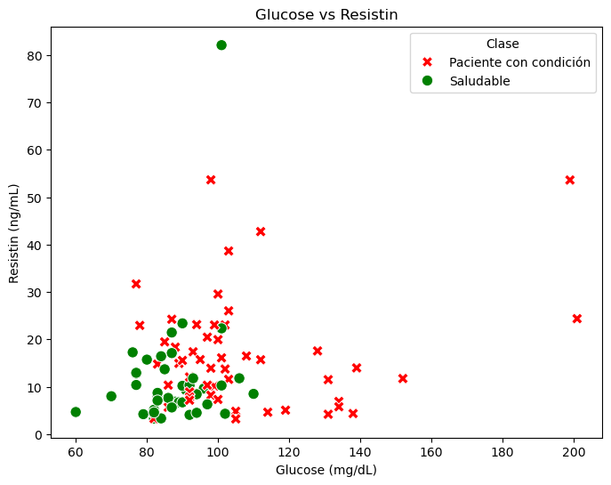

```python
from sklearn.discriminant_analysis import LinearDiscriminantAnalysis as LDA
import seaborn as sns
import matplotlib.pyplot as plt
XLDA= X_trainvar
YLDA= y_train
lda= LDA()
lda.fit(XLDA, YLDA)
discproy= lda.transform(XLDA)
print("Coeficientes disc/LDA: ", lda.coef_)
print("Intercepto en los datos: ", lda.intercept_)
df_plot = X_trainvar.copy()
df_plot["Class"] = y_train.values

class_map = {0: "Saludable", 1: "Paciente con condición"}
df_plot["ClassLabel"] = df_plot["Class"].map(class_map)

palette = {"Saludable": "green", "Paciente con condición": "red"}
markers = {"Saludable": "o", "Paciente con condición": "X"}

plt.figure(figsize=(8,6))
sns.scatterplot(data=df_plot, x="Glucose", y="Resistin", hue="ClassLabel", style="ClassLabel", palette=palette, markers=markers, s=80)
plt.title("Glucose vs Resistin")
plt.xlabel("Glucose (mg/dL)")
plt.ylabel("Resistin (ng/mL)")
plt.legend(title="Clase")
plt.show()
```